# Risk Factor Analysis

## Outcome Variable

**Outcome Variable:** whz

## Predictor Variables

**Intervention Variable:** mage

**Adjustment Set:**

- arm
- meducyrs
- feducyrs
- W_mhtcm
- W_mwtkg
- W_mbmi
- single
- delta_meducyrs
- delta_feducyrs
- delta_W_mhtcm
- delta_W_mwtkg
- delta_W_mbmi
- delta_single

## Stratifying Variables

The analysis was stratified on these variable(s):

- agecat
- studyid
- country

## Data Summary

| agecat | studyid | country | mage | n_cell | n | outcome_variable |
| --- | --- | --- | --- | --- | --- | --- |
| Birth | CMC-V-BCS-2002 | INDIA | [20-30) | 75 | 86 | whz |
| Birth | CMC-V-BCS-2002 | INDIA | <20 | 7 | 86 | whz |
| Birth | CMC-V-BCS-2002 | INDIA | >=30 | 4 | 86 | whz |
| Birth | COHORTS | GUATEMALA | [20-30) | 367 | 756 | whz |
| Birth | COHORTS | GUATEMALA | <20 | 101 | 756 | whz |
| Birth | COHORTS | GUATEMALA | >=30 | 288 | 756 | whz |
| Birth | COHORTS | INDIA | [20-30) | 2965 | 4405 | whz |
| Birth | COHORTS | INDIA | <20 | 337 | 4405 | whz |
| Birth | COHORTS | INDIA | >=30 | 1103 | 4405 | whz |
| Birth | COHORTS | PHILIPPINES | [20-30) | 1744 | 2899 | whz |
| Birth | COHORTS | PHILIPPINES | <20 | 354 | 2899 | whz |
| Birth | COHORTS | PHILIPPINES | >=30 | 801 | 2899 | whz |
| Birth | EE | PAKISTAN | [20-30) | 68 | 177 | whz |
| Birth | EE | PAKISTAN | <20 | 1 | 177 | whz |
| Birth | EE | PAKISTAN | >=30 | 108 | 177 | whz |
| Birth | GMS-Nepal | NEPAL | [20-30) | 421 | 641 | whz |
| Birth | GMS-Nepal | NEPAL | <20 | 125 | 641 | whz |
| Birth | GMS-Nepal | NEPAL | >=30 | 95 | 641 | whz |
| Birth | IRC | INDIA | [20-30) | 289 | 343 | whz |
| Birth | IRC | INDIA | <20 | 28 | 343 | whz |
| Birth | IRC | INDIA | >=30 | 26 | 343 | whz |
| Birth | JiVitA-3 | BANGLADESH | [20-30) | 9028 | 18006 | whz |
| Birth | JiVitA-3 | BANGLADESH | <20 | 7251 | 18006 | whz |
| Birth | JiVitA-3 | BANGLADESH | >=30 | 1727 | 18006 | whz |
| Birth | Keneba | GAMBIA | [20-30) | 670 | 1466 | whz |
| Birth | Keneba | GAMBIA | <20 | 224 | 1466 | whz |
| Birth | Keneba | GAMBIA | >=30 | 572 | 1466 | whz |
| Birth | MAL-ED | BANGLADESH | [20-30) | 148 | 215 | whz |
| Birth | MAL-ED | BANGLADESH | <20 | 28 | 215 | whz |
| Birth | MAL-ED | BANGLADESH | >=30 | 39 | 215 | whz |

[output cut: 183 more lines]

The following strata were considered:

- agecat: 24 months, studyid: CMC-V-BCS-2002, country: INDIA
- agecat: 24 months, studyid: COHORTS, country: GUATEMALA
- agecat: 24 months, studyid: COHORTS, country: INDIA
- agecat: 24 months, studyid: COHORTS, country: PHILIPPINES
- agecat: 24 months, studyid: EE, country: PAKISTAN
- agecat: 24 months, studyid: GMS-Nepal, country: NEPAL
- agecat: 24 months, studyid: IRC, country: INDIA
- agecat: 24 months, studyid: JiVitA-3, country: BANGLADESH
- agecat: 24 months, studyid: Keneba, country: GAMBIA
- agecat: 24 months, studyid: LCNI-5, country: MALAWI
- agecat: 24 months, studyid: MAL-ED, country: BANGLADESH
- agecat: 24 months, studyid: MAL-ED, country: BRAZIL
- agecat: 24 months, studyid: MAL-ED, country: INDIA
- agecat: 24 months, studyid: MAL-ED, country: NEPAL
- agecat: 24 months, studyid: MAL-ED, country: PERU
- agecat: 24 months, studyid: MAL-ED, country: SOUTH AFRICA
- agecat: 24 months, studyid: MAL-ED, country: TANZANIA, UNITED REPUBLIC OF
- agecat: 24 months, studyid: NIH-Birth, country: BANGLADESH
- agecat: 24 months, studyid: NIH-Crypto, country: BANGLADESH
- agecat: 24 months, studyid: PROBIT, country: BELARUS
- agecat: 24 months, studyid: PROVIDE, country: BANGLADESH
- agecat: 24 months, studyid: TanzaniaChild2, country: TANZANIA, UNITED REPUBLIC OF
- agecat: 24 months, studyid: ZVITAMBO, country: ZIMBABWE
- agecat: 6 months, studyid: CMC-V-BCS-2002, country: INDIA
- agecat: 6 months, studyid: COHORTS, country: GUATEMALA
- agecat: 6 months, studyid: COHORTS, country: INDIA
- agecat: 6 months, studyid: COHORTS, country: PHILIPPINES
- agecat: 6 months, studyid: EE, country: PAKISTAN
- agecat: 6 months, studyid: GMS-Nepal, country: NEPAL
- agecat: 6 months, studyid: Guatemala BSC, country: GUATEMALA
- agecat: 6 months, studyid: IRC, country: INDIA
- agecat: 6 months, studyid: JiVitA-3, country: BANGLADESH
- agecat: 6 months, studyid: Keneba, country: GAMBIA
- agecat: 6 months, studyid: LCNI-5, country: MALAWI
- agecat: 6 months, studyid: MAL-ED, country: BANGLADESH
- agecat: 6 months, studyid: MAL-ED, country: BRAZIL
- agecat: 6 months, studyid: MAL-ED, country: INDIA
- agecat: 6 months, studyid: MAL-ED, country: NEPAL
- agecat: 6 months, studyid: MAL-ED, country: PERU
- agecat: 6 months, studyid: MAL-ED, country: SOUTH AFRICA
- agecat: 6 months, studyid: MAL-ED, country: TANZANIA, UNITED REPUBLIC OF
- agecat: 6 months, studyid: NIH-Birth, country: BANGLADESH
- agecat: 6 months, studyid: NIH-Crypto, country: BANGLADESH
- agecat: 6 months, studyid: PROBIT, country: BELARUS
- agecat: 6 months, studyid: PROVIDE, country: BANGLADESH
- agecat: 6 months, studyid: SAS-CompFeed, country: INDIA
- agecat: 6 months, studyid: SAS-FoodSuppl, country: INDIA
- agecat: 6 months, studyid: TanzaniaChild2, country: TANZANIA, UNITED REPUBLIC OF
- agecat: 6 months, studyid: ZVITAMBO, country: ZIMBABWE
- agecat: Birth, studyid: CMC-V-BCS-2002, country: INDIA
- agecat: Birth, studyid: COHORTS, country: GUATEMALA
- agecat: Birth, studyid: COHORTS, country: INDIA
- agecat: Birth, studyid: COHORTS, country: PHILIPPINES
- agecat: Birth, studyid: EE, country: PAKISTAN
- agecat: Birth, studyid: GMS-Nepal, country: NEPAL
- agecat: Birth, studyid: IRC, country: INDIA
- agecat: Birth, studyid: JiVitA-3, country: BANGLADESH
- agecat: Birth, studyid: Keneba, country: GAMBIA
- agecat: Birth, studyid: MAL-ED, country: BANGLADESH
- agecat: Birth, studyid: MAL-ED, country: BRAZIL
- agecat: Birth, studyid: MAL-ED, country: INDIA
- agecat: Birth, studyid: MAL-ED, country: NEPAL
- agecat: Birth, studyid: MAL-ED, country: PERU
- agecat: Birth, studyid: MAL-ED, country: SOUTH AFRICA
- agecat: Birth, studyid: MAL-ED, country: TANZANIA, UNITED REPUBLIC OF
- agecat: Birth, studyid: NIH-Birth, country: BANGLADESH
- agecat: Birth, studyid: NIH-Crypto, country: BANGLADESH
- agecat: Birth, studyid: PROBIT, country: BELARUS
- agecat: Birth, studyid: PROVIDE, country: BANGLADESH
- agecat: Birth, studyid: SAS-CompFeed, country: INDIA
- agecat: Birth, studyid: ZVITAMBO, country: ZIMBABWE

### Dropped Strata

Some strata were dropped due to rare outcomes:

- agecat: Birth, studyid: CMC-V-BCS-2002, country: INDIA
- agecat: Birth, studyid: EE, country: PAKISTAN
- agecat: Birth, studyid: MAL-ED, country: INDIA
- agecat: Birth, studyid: MAL-ED, country: NEPAL
- agecat: 6 months, studyid: EE, country: PAKISTAN
- agecat: 24 months, studyid: EE, country: PAKISTAN
- agecat: 24 months, studyid: MAL-ED, country: NEPAL
- agecat: 24 months, studyid: TanzaniaChild2, country: TANZANIA, UNITED REPUBLIC OF

## Methods Detail

We’re interested in the causal parameters $E[Y_a]$ for all values of $a \in \mathcal{A}$. These parameters represent the mean outcome if, possibly contrary to fact, we intervened to set all units to have $A=a$. Under the randomization and positivity assumptions, these are identified by the statistical parameters $\psi_a=E_W[E_{Y|A,W}(Y|A=a,W)]$. In addition, we’re interested in the mean of $Y$, $E[Y]$ under no intervention (the observed mean). We will estimate these parameters by using SuperLearner to fit the relevant likelihood factors – $E_{Y|A,W}(Y|A=a,W)$ and $p(A=a|W)$, and then updating our likelihood fit using a joint TMLE.

For unadjusted analyses ($W=\{\}$), initial likelihoods were estimated using Lrnr_glm to estimate the simple $E(Y|A)$ and Lrnr_mean to estimate $p(A)$. For adjusted analyses, a small library containing Lrnr_glmnet, Lrnr_xgboost, and Lrnr_mean was used.

Having estimated these parameters, we will then use the delta method to estimate relative risks and attributable risks relative to a prespecified baseline level of $A$.

# Results Detail

## Results Plots

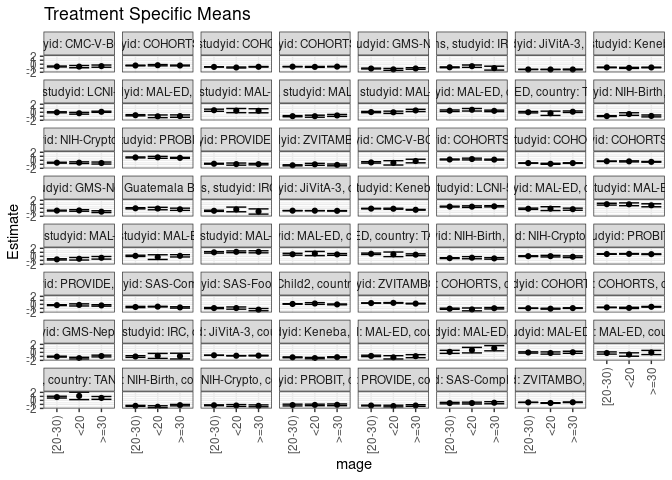

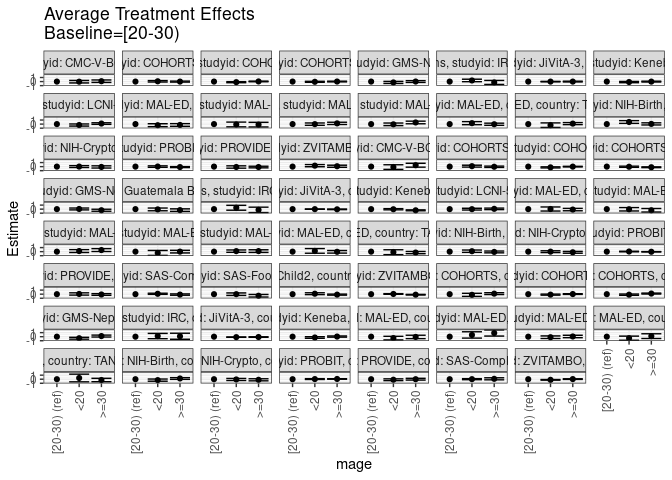

[figure not shown]

## Results Table

### Parameter: TSM

| agecat | studyid | country | intervention_level | baseline_level | estimate | ci_lower | ci_upper |
| --- | --- | --- | --- | --- | --- | --- | --- |
| Birth | COHORTS | GUATEMALA | [20-30) | NA | -1.1009252 | -1.2409041 | -0.9609464 |
| Birth | COHORTS | GUATEMALA | <20 | NA | -1.2649867 | -1.6185421 | -0.9114313 |
| Birth | COHORTS | GUATEMALA | >=30 | NA | -0.9704383 | -1.1462086 | -0.7946680 |
| Birth | COHORTS | INDIA | [20-30) | NA | -0.9691873 | -1.0114751 | -0.9268995 |
| Birth | COHORTS | INDIA | <20 | NA | -1.0875856 | -1.2096807 | -0.9654905 |
| Birth | COHORTS | INDIA | >=30 | NA | -0.9416220 | -1.0181060 | -0.8651379 |
| Birth | COHORTS | PHILIPPINES | [20-30) | NA | -0.7633093 | -0.8240118 | -0.7026067 |
| Birth | COHORTS | PHILIPPINES | <20 | NA | -0.8902706 | -1.0324184 | -0.7481228 |
| Birth | COHORTS | PHILIPPINES | >=30 | NA | -0.6134238 | -0.7002891 | -0.5265586 |
| Birth | GMS-Nepal | NEPAL | [20-30) | NA | -1.0665055 | -1.1744861 | -0.9585248 |
| Birth | GMS-Nepal | NEPAL | <20 | NA | -1.4439205 | -1.6477695 | -1.2400716 |
| Birth | GMS-Nepal | NEPAL | >=30 | NA | -0.9125898 | -1.1278492 | -0.6973305 |
| Birth | IRC | INDIA | [20-30) | NA | -1.0358870 | -1.2422971 | -0.8294769 |
| Birth | IRC | INDIA | <20 | NA | -0.8774918 | -1.4988787 | -0.2561048 |
| Birth | IRC | INDIA | >=30 | NA | -0.9311075 | -1.6451767 | -0.2170384 |
| Birth | JiVitA-3 | BANGLADESH | [20-30) | NA | -0.7262191 | -0.7516283 | -0.7008099 |
| Birth | JiVitA-3 | BANGLADESH | <20 | NA | -0.8393060 | -0.8677654 | -0.8108467 |
| Birth | JiVitA-3 | BANGLADESH | >=30 | NA | -0.8101127 | -0.8776052 | -0.7426203 |
| Birth | Keneba | GAMBIA | [20-30) | NA | -1.2350733 | -1.3277724 | -1.1423743 |
| Birth | Keneba | GAMBIA | <20 | NA | -1.4351254 | -1.5986855 | -1.2715652 |
| Birth | Keneba | GAMBIA | >=30 | NA | -1.2048571 | -1.3103055 | -1.0994086 |
| Birth | MAL-ED | BANGLADESH | [20-30) | NA | -0.8907824 | -1.0599463 | -0.7216186 |
| Birth | MAL-ED | BANGLADESH | <20 | NA | -1.2443906 | -1.6594063 | -0.8293748 |
| Birth | MAL-ED | BANGLADESH | >=30 | NA | -0.9538537 | -1.3343480 | -0.5733594 |
| Birth | MAL-ED | BRAZIL | [20-30) | NA | 0.1282051 | -0.2476806 | 0.5040909 |
| Birth | MAL-ED | BRAZIL | <20 | NA | 0.5562500 | -0.1284217 | 1.2409217 |
| Birth | MAL-ED | BRAZIL | >=30 | NA | 1.0353333 | 0.3801713 | 1.6904954 |
| Birth | MAL-ED | PERU | [20-30) | NA | -0.0301014 | -0.1884654 | 0.1282626 |
| Birth | MAL-ED | PERU | <20 | NA | -0.1591319 | -0.4296966 | 0.1114328 |
| Birth | MAL-ED | PERU | >=30 | NA | 0.0213440 | -0.2333719 | 0.2760600 |

[output cut: 159 more lines]

### Parameter: E(Y)

| agecat | studyid | country | intervention_level | baseline_level | estimate | ci_lower | ci_upper |
| --- | --- | --- | --- | --- | --- | --- | --- |
| Birth | COHORTS | GUATEMALA | NA | NA | -1.0621429 | -1.1631387 | -0.9611471 |
| Birth | COHORTS | INDIA | NA | NA | -0.9742815 | -1.0093427 | -0.9392203 |
| Birth | COHORTS | PHILIPPINES | NA | NA | -0.7427251 | -0.7890855 | -0.6963647 |
| Birth | GMS-Nepal | NEPAL | NA | NA | -1.1164431 | -1.2040134 | -1.0288728 |
| Birth | IRC | INDIA | NA | NA | -1.0105831 | -1.1973019 | -0.8238643 |
| Birth | JiVitA-3 | BANGLADESH | NA | NA | -0.7777196 | -0.7967334 | -0.7587059 |
| Birth | Keneba | GAMBIA | NA | NA | -1.2349454 | -1.2972413 | -1.1726496 |
| Birth | MAL-ED | BANGLADESH | NA | NA | -0.9418605 | -1.0869834 | -0.7967375 |
| Birth | MAL-ED | BRAZIL | NA | NA | 0.4029032 | 0.0896793 | 0.7161272 |
| Birth | MAL-ED | PERU | NA | NA | -0.0520175 | -0.1725298 | 0.0684947 |
| Birth | MAL-ED | SOUTH AFRICA | NA | NA | -0.1925833 | -0.4053570 | 0.0201904 |
| Birth | MAL-ED | TANZANIA, UNITED REPUBLIC OF | NA | NA | 0.7624348 | 0.5710709 | 0.9537986 |
| Birth | NIH-Birth | BANGLADESH | NA | NA | -1.3545637 | -1.4492090 | -1.2599184 |
| Birth | NIH-Crypto | BANGLADESH | NA | NA | -1.2441513 | -1.3281130 | -1.1601897 |
| Birth | PROBIT | BELARUS | NA | NA | -1.1491782 | -1.3593933 | -0.9389630 |
| Birth | PROVIDE | BANGLADESH | NA | NA | -1.2984586 | -1.3752758 | -1.2216415 |
| Birth | SAS-CompFeed | INDIA | NA | NA | -0.6700453 | -0.8474950 | -0.4925957 |
| Birth | ZVITAMBO | ZIMBABWE | NA | NA | -0.5144298 | -0.5403185 | -0.4885410 |
| 6 months | CMC-V-BCS-2002 | INDIA | NA | NA | -0.5026766 | -0.6536848 | -0.3516685 |
| 6 months | COHORTS | GUATEMALA | NA | NA | 0.1940810 | 0.1226351 | 0.2655269 |
| 6 months | COHORTS | INDIA | NA | NA | -0.7119298 | -0.7444861 | -0.6793734 |
| 6 months | COHORTS | PHILIPPINES | NA | NA | -0.2938433 | -0.3352064 | -0.2524802 |
| 6 months | GMS-Nepal | NEPAL | NA | NA | -0.6038416 | -0.6899448 | -0.5177384 |
| 6 months | Guatemala BSC | GUATEMALA | NA | NA | -0.0619988 | -0.1773839 | 0.0533863 |
| 6 months | IRC | INDIA | NA | NA | -0.5989297 | -0.7344491 | -0.4634104 |
| 6 months | JiVitA-3 | BANGLADESH | NA | NA | -0.5933575 | -0.6128938 | -0.5738211 |
| 6 months | Keneba | GAMBIA | NA | NA | -0.1833609 | -0.2343611 | -0.1323607 |
| 6 months | LCNI-5 | MALAWI | NA | NA | 0.4409268 | 0.3613957 | 0.5204578 |
| 6 months | MAL-ED | BANGLADESH | NA | NA | -0.1376763 | -0.2664642 | -0.0088885 |
| 6 months | MAL-ED | BRAZIL | NA | NA | 0.9720774 | 0.8078144 | 1.1363403 |
| 6 months | MAL-ED | INDIA | NA | NA | -0.7077885 | -0.8346769 | -0.5809000 |
| 6 months | MAL-ED | NEPAL | NA | NA | 0.1104308 | -0.0208643 | 0.2417259 |
| 6 months | MAL-ED | PERU | NA | NA | 1.0528816 | 0.9313005 | 1.1744626 |
| 6 months | MAL-ED | SOUTH AFRICA | NA | NA | 0.5421785 | 0.3900443 | 0.6943126 |
| 6 months | MAL-ED | TANZANIA, UNITED REPUBLIC OF | NA | NA | 0.5362213 | 0.4049390 | 0.6675036 |
| 6 months | NIH-Birth | BANGLADESH | NA | NA | -0.4495343 | -0.5402027 | -0.3588659 |
| 6 months | NIH-Crypto | BANGLADESH | NA | NA | 0.0297622 | -0.0491685 | 0.1086930 |
| 6 months | PROBIT | BELARUS | NA | NA | 0.5741099 | 0.5141290 | 0.6340908 |
| 6 months | PROVIDE | BANGLADESH | NA | NA | -0.1990907 | -0.2817968 | -0.1163845 |
| 6 months | SAS-CompFeed | INDIA | NA | NA | -0.6657084 | -0.8024377 | -0.5289791 |
| 6 months | SAS-FoodSuppl | INDIA | NA | NA | -1.0121579 | -1.1280429 | -0.8962729 |
| 6 months | TanzaniaChild2 | TANZANIA, UNITED REPUBLIC OF | NA | NA | 0.0782666 | 0.0252568 | 0.1312764 |
| 6 months | ZVITAMBO | ZIMBABWE | NA | NA | 0.3103322 | 0.2846161 | 0.3360483 |
| 24 months | CMC-V-BCS-2002 | INDIA | NA | NA | -0.5571505 | -0.6585247 | -0.4557763 |
| 24 months | COHORTS | GUATEMALA | NA | NA | -0.2813755 | -0.3354674 | -0.2272835 |
| 24 months | COHORTS | INDIA | NA | NA | -0.6627749 | -0.6962103 | -0.6293395 |
| 24 months | COHORTS | PHILIPPINES | NA | NA | -0.6099592 | -0.6467541 | -0.5731643 |
| 24 months | GMS-Nepal | NEPAL | NA | NA | -1.1363107 | -1.2252817 | -1.0473398 |
| 24 months | IRC | INDIA | NA | NA | -0.7458150 | -0.8368180 | -0.6548120 |
| 24 months | JiVitA-3 | BANGLADESH | NA | NA | -1.2977181 | -1.3209986 | -1.2744376 |
| 24 months | Keneba | GAMBIA | NA | NA | -0.8079199 | -0.8550714 | -0.7607684 |
| 24 months | LCNI-5 | MALAWI | NA | NA | -0.0115944 | -0.1019822 | 0.0787935 |
| 24 months | MAL-ED | BANGLADESH | NA | NA | -0.8192925 | -0.9412667 | -0.6973182 |
| 24 months | MAL-ED | BRAZIL | NA | NA | 0.4626233 | 0.2567495 | 0.6684971 |
| 24 months | MAL-ED | INDIA | NA | NA | -0.9564667 | -1.0725632 | -0.8403701 |
| 24 months | MAL-ED | PERU | NA | NA | 0.1111982 | -0.0118399 | 0.2342362 |
| 24 months | MAL-ED | SOUTH AFRICA | NA | NA | 0.4090301 | 0.2879441 | 0.5301161 |
| 24 months | MAL-ED | TANZANIA, UNITED REPUBLIC OF | NA | NA | 0.0547975 | -0.0703378 | 0.1799328 |
| 24 months | NIH-Birth | BANGLADESH | NA | NA | -0.9097790 | -1.0080462 | -0.8115117 |
| 24 months | NIH-Crypto | BANGLADESH | NA | NA | -0.6103502 | -0.7050157 | -0.5156847 |
| 24 months | PROBIT | BELARUS | NA | NA | 0.6981406 | 0.5843775 | 0.8119038 |
| 24 months | PROVIDE | BANGLADESH | NA | NA | -0.8928670 | -0.9755153 | -0.8102187 |
| 24 months | ZVITAMBO | ZIMBABWE | NA | NA | -1.1845602 | -1.2836321 | -1.0854883 |

### Parameter: ATE

| agecat | studyid | country | intervention_level | baseline_level | estimate | ci_lower | ci_upper |
| --- | --- | --- | --- | --- | --- | --- | --- |
| Birth | COHORTS | GUATEMALA | [20-30) | [20-30) | 0.0000000 | 0.0000000 | 0.0000000 |
| Birth | COHORTS | GUATEMALA | <20 | [20-30) | -0.1640615 | -0.5432369 | 0.2151138 |
| Birth | COHORTS | GUATEMALA | >=30 | [20-30) | 0.1304869 | -0.0925628 | 0.3535366 |
| Birth | COHORTS | INDIA | [20-30) | [20-30) | 0.0000000 | 0.0000000 | 0.0000000 |
| Birth | COHORTS | INDIA | <20 | [20-30) | -0.1183983 | -0.2476705 | 0.0108738 |
| Birth | COHORTS | INDIA | >=30 | [20-30) | 0.0275653 | -0.0598815 | 0.1150122 |
| Birth | COHORTS | PHILIPPINES | [20-30) | [20-30) | 0.0000000 | 0.0000000 | 0.0000000 |
| Birth | COHORTS | PHILIPPINES | <20 | [20-30) | -0.1269613 | -0.2816291 | 0.0277065 |
| Birth | COHORTS | PHILIPPINES | >=30 | [20-30) | 0.1498854 | 0.0440069 | 0.2557639 |
| Birth | GMS-Nepal | NEPAL | [20-30) | [20-30) | 0.0000000 | 0.0000000 | 0.0000000 |
| Birth | GMS-Nepal | NEPAL | <20 | [20-30) | -0.3774151 | -0.6081530 | -0.1466771 |
| Birth | GMS-Nepal | NEPAL | >=30 | [20-30) | 0.1539156 | -0.0865318 | 0.3943631 |
| Birth | IRC | INDIA | [20-30) | [20-30) | 0.0000000 | 0.0000000 | 0.0000000 |
| Birth | IRC | INDIA | <20 | [20-30) | 0.1583952 | -0.4951415 | 0.8119320 |
| Birth | IRC | INDIA | >=30 | [20-30) | 0.1047795 | -0.6381204 | 0.8476794 |
| Birth | JiVitA-3 | BANGLADESH | [20-30) | [20-30) | 0.0000000 | 0.0000000 | 0.0000000 |
| Birth | JiVitA-3 | BANGLADESH | <20 | [20-30) | -0.1130869 | -0.1484413 | -0.0777326 |
| Birth | JiVitA-3 | BANGLADESH | >=30 | [20-30) | -0.0838936 | -0.1538955 | -0.0138918 |
| Birth | Keneba | GAMBIA | [20-30) | [20-30) | 0.0000000 | 0.0000000 | 0.0000000 |
| Birth | Keneba | GAMBIA | <20 | [20-30) | -0.2000520 | -0.3880533 | -0.0120508 |
| Birth | Keneba | GAMBIA | >=30 | [20-30) | 0.0302163 | -0.1099254 | 0.1703579 |
| Birth | MAL-ED | BANGLADESH | [20-30) | [20-30) | 0.0000000 | 0.0000000 | 0.0000000 |
| Birth | MAL-ED | BANGLADESH | <20 | [20-30) | -0.3536081 | -0.8017093 | 0.0944930 |
| Birth | MAL-ED | BANGLADESH | >=30 | [20-30) | -0.0630713 | -0.4808563 | 0.3547137 |
| Birth | MAL-ED | BRAZIL | [20-30) | [20-30) | 0.0000000 | 0.0000000 | 0.0000000 |
| Birth | MAL-ED | BRAZIL | <20 | [20-30) | 0.4280449 | -0.3530220 | 1.2091117 |
| Birth | MAL-ED | BRAZIL | >=30 | [20-30) | 0.9071282 | 0.1517955 | 1.6624609 |
| Birth | MAL-ED | PERU | [20-30) | [20-30) | 0.0000000 | 0.0000000 | 0.0000000 |
| Birth | MAL-ED | PERU | <20 | [20-30) | -0.1290305 | -0.4429297 | 0.1848688 |
| Birth | MAL-ED | PERU | >=30 | [20-30) | 0.0514454 | -0.2482201 | 0.3511110 |

[output cut: 159 more lines]

### Parameter: PAR

| agecat | studyid | country | intervention_level | baseline_level | estimate | ci_lower | ci_upper |
| --- | --- | --- | --- | --- | --- | --- | --- |
| Birth | COHORTS | GUATEMALA | [20-30) | NA | 0.0387824 | -0.0676935 | 0.1452582 |
| Birth | COHORTS | INDIA | [20-30) | NA | -0.0050942 | -0.0307855 | 0.0205971 |
| Birth | COHORTS | PHILIPPINES | [20-30) | NA | 0.0205842 | -0.0178704 | 0.0590388 |
| Birth | GMS-Nepal | NEPAL | [20-30) | NA | -0.0499376 | -0.1143618 | 0.0144866 |
| Birth | IRC | INDIA | [20-30) | NA | 0.0253039 | -0.0496193 | 0.1002271 |
| Birth | JiVitA-3 | BANGLADESH | [20-30) | NA | -0.0515005 | -0.0682568 | -0.0347443 |
| Birth | Keneba | GAMBIA | [20-30) | NA | 0.0001279 | -0.0694845 | 0.0697403 |
| Birth | MAL-ED | BANGLADESH | [20-30) | NA | -0.0510780 | -0.1535796 | 0.0514235 |
| Birth | MAL-ED | BRAZIL | [20-30) | NA | 0.2746981 | 0.0264094 | 0.5229868 |
| Birth | MAL-ED | PERU | [20-30) | NA | -0.0219161 | -0.1439872 | 0.1001549 |
| Birth | MAL-ED | SOUTH AFRICA | [20-30) | NA | -0.0282184 | -0.2235359 | 0.1670990 |
| Birth | MAL-ED | TANZANIA, UNITED REPUBLIC OF | [20-30) | NA | -0.0562016 | -0.2275676 | 0.1151644 |
| Birth | NIH-Birth | BANGLADESH | [20-30) | NA | 0.0117449 | -0.0505608 | 0.0740506 |
| Birth | NIH-Crypto | BANGLADESH | [20-30) | NA | -0.0260486 | -0.0879327 | 0.0358356 |
| Birth | PROBIT | BELARUS | [20-30) | NA | 0.0165411 | -0.0012201 | 0.0343023 |
| Birth | PROVIDE | BANGLADESH | [20-30) | NA | -0.0125472 | -0.0641741 | 0.0390798 |
| Birth | SAS-CompFeed | INDIA | [20-30) | NA | 0.0103093 | -0.0264107 | 0.0470292 |
| Birth | ZVITAMBO | ZIMBABWE | [20-30) | NA | -0.0181635 | -0.0374292 | 0.0011022 |
| 6 months | CMC-V-BCS-2002 | INDIA | [20-30) | NA | 0.0285744 | -0.0485873 | 0.1057360 |
| 6 months | COHORTS | GUATEMALA | [20-30) | NA | -0.0062463 | -0.0821048 | 0.0696122 |
| 6 months | COHORTS | INDIA | [20-30) | NA | -0.0182775 | -0.0414023 | 0.0048473 |
| 6 months | COHORTS | PHILIPPINES | [20-30) | NA | -0.0544230 | -0.0901422 | -0.0187039 |
| 6 months | GMS-Nepal | NEPAL | [20-30) | NA | -0.0298320 | -0.0921363 | 0.0324722 |
| 6 months | Guatemala BSC | GUATEMALA | [20-30) | NA | -0.0620913 | -0.1574855 | 0.0333030 |
| 6 months | IRC | INDIA | [20-30) | NA | 0.0196839 | -0.0504778 | 0.0898456 |
| 6 months | JiVitA-3 | BANGLADESH | [20-30) | NA | -0.0056427 | -0.0261951 | 0.0149097 |
| 6 months | Keneba | GAMBIA | [20-30) | NA | -0.1035826 | -0.1591603 | -0.0480049 |
| 6 months | LCNI-5 | MALAWI | [20-30) | NA | 0.0184138 | -0.0548017 | 0.0916294 |
| 6 months | MAL-ED | BANGLADESH | [20-30) | NA | -0.0234731 | -0.1171369 | 0.0701906 |
| 6 months | MAL-ED | BRAZIL | [20-30) | NA | -0.0561211 | -0.1980832 | 0.0858410 |
| 6 months | MAL-ED | INDIA | [20-30) | NA | 0.0522034 | -0.0120574 | 0.1164642 |
| 6 months | MAL-ED | NEPAL | [20-30) | NA | -0.0058125 | -0.0715975 | 0.0599726 |
| 6 months | MAL-ED | PERU | [20-30) | NA | 0.0609537 | -0.0663526 | 0.1882601 |
| 6 months | MAL-ED | SOUTH AFRICA | [20-30) | NA | 0.0245030 | -0.1428057 | 0.1918116 |
| 6 months | MAL-ED | TANZANIA, UNITED REPUBLIC OF | [20-30) | NA | -0.0989537 | -0.2270518 | 0.0291444 |
| 6 months | NIH-Birth | BANGLADESH | [20-30) | NA | 0.0025393 | -0.0633977 | 0.0684763 |
| 6 months | NIH-Crypto | BANGLADESH | [20-30) | NA | -0.0163784 | -0.0754992 | 0.0427424 |
| 6 months | PROBIT | BELARUS | [20-30) | NA | 0.0028609 | -0.0080735 | 0.0137954 |
| 6 months | PROVIDE | BANGLADESH | [20-30) | NA | -0.0056430 | -0.0576716 | 0.0463857 |
| 6 months | SAS-CompFeed | INDIA | [20-30) | NA | -0.0006555 | -0.0321461 | 0.0308350 |
| 6 months | SAS-FoodSuppl | INDIA | [20-30) | NA | -0.0805261 | -0.1625921 | 0.0015399 |
| 6 months | TanzaniaChild2 | TANZANIA, UNITED REPUBLIC OF | [20-30) | NA | -0.0202096 | -0.0600796 | 0.0196605 |
| 6 months | ZVITAMBO | ZIMBABWE | [20-30) | NA | -0.0077237 | -0.0287647 | 0.0133173 |
| 24 months | CMC-V-BCS-2002 | INDIA | [20-30) | NA | 0.0049747 | -0.0409317 | 0.0508810 |
| 24 months | COHORTS | GUATEMALA | [20-30) | NA | 0.0320351 | -0.0245605 | 0.0886306 |
| 24 months | COHORTS | INDIA | [20-30) | NA | 0.0039298 | -0.0192123 | 0.0270719 |
| 24 months | COHORTS | PHILIPPINES | [20-30) | NA | -0.0079256 | -0.0386842 | 0.0228331 |
| 24 months | GMS-Nepal | NEPAL | [20-30) | NA | -0.0681051 | -0.1349113 | -0.0012989 |
| 24 months | IRC | INDIA | [20-30) | NA | 0.0109435 | -0.0313915 | 0.0532785 |
| 24 months | JiVitA-3 | BANGLADESH | [20-30) | NA | 0.0001131 | -0.0258322 | 0.0260584 |
| 24 months | Keneba | GAMBIA | [20-30) | NA | -0.0145671 | -0.0668378 | 0.0377037 |
| 24 months | LCNI-5 | MALAWI | [20-30) | NA | 0.0039618 | -0.0806050 | 0.0885286 |
| 24 months | MAL-ED | BANGLADESH | [20-30) | NA | -0.0791131 | -0.1605634 | 0.0023373 |
| 24 months | MAL-ED | BRAZIL | [20-30) | NA | -0.0447076 | -0.2215838 | 0.1321685 |
| 24 months | MAL-ED | INDIA | [20-30) | NA | 0.0150599 | -0.0394344 | 0.0695542 |
| 24 months | MAL-ED | PERU | [20-30) | NA | 0.0612531 | -0.0668231 | 0.1893293 |
| 24 months | MAL-ED | SOUTH AFRICA | [20-30) | NA | 0.0246799 | -0.1153507 | 0.1647105 |
| 24 months | MAL-ED | TANZANIA, UNITED REPUBLIC OF | [20-30) | NA | 0.0400925 | -0.0781403 | 0.1583253 |
| 24 months | NIH-Birth | BANGLADESH | [20-30) | NA | 0.0531031 | -0.0178122 | 0.1240184 |
| 24 months | NIH-Crypto | BANGLADESH | [20-30) | NA | -0.0071676 | -0.0738031 | 0.0594680 |
| 24 months | PROBIT | BELARUS | [20-30) | NA | -0.0144020 | -0.0611936 | 0.0323895 |
| 24 months | PROVIDE | BANGLADESH | [20-30) | NA | -0.0340229 | -0.0860057 | 0.0179599 |
| 24 months | ZVITAMBO | ZIMBABWE | [20-30) | NA | 0.0646538 | -0.0109983 | 0.1403059 |